# Lab4_25_26_Hugo_Garcia_Souto

### Notebook Completion Note

**Student:** Hugo García Souto

This notebook has been successfully completed following the provided guidelines. All the indicated exercises and cells have been resolved.

- **Preserved Instructions:** The original instructions found within the code cells have been kept as **commented lines** (`#`) to maintain the context of each task.
- **Code Documentation:** Brief explanations and comments have been added to the solution code to clarify the logic and the steps taken.
- **Answers to Questions:** All questions posed within the exercises have been answered. Single questions are addressed immediately below the prompt, while exercises containing multiple questions have their answers grouped in a consolidated block at the end of the exercise.

### Topic 4: Image Segmentation

### Part 1: intensity-based thresholding and clustering (0.80 pts.)

Remember: digital images are just two-dimensional data. To segment a certain type of images, we always need some prior knowledge of the information that is available in the data. Here, we assume that the useful information is given by more or less similar gray values and that the foreground consist of typical objects as seen in out daily live.

## Master in Artificial Intelligence, UdC, USC, UVigo. 2025/2026

## COMPUTER VISION I

Make sure the path to the image file meets your needs on your system.

```python
images_path = './images/'
```

We import everything at the beginning, as the libs are needed later...

```python
# !pip install seaborn opencv-python scikit-learn scipy matplotlib numpy
```

```python
import sys
import os
import numpy as np
import cv2
from matplotlib import pyplot as plt
import seaborn as sns
from sklearn import mixture
from sklearn.cluster import KMeans, MeanShift, estimate_bandwidth, DBSCAN
from scipy.stats import norm

plt.rcParams.update({"axes.grid" : True})
```

We instruct matplotlib to show gridlines in the visualization of two-dimensional data (maybe this is already the default in your environment). Decide by yourself whether you like them to be displayed.

```python
plt.rcParams.update({"axes.grid" : True})
```

#### Histogram thresholding

**Exercise 1:** Read and visualize 'plates.png', and:

1. Calculate its histogram, and visualize it using matplotlib and pyplot

(1_intro_CV notebook).

1. Do the same using the “seaborn” package.
2. Compute a smoothed version of the histogram by using a kernel density

estimation (KDE) from the “seaborn” package.

**Key Concepts**

***Histogram***: Graphical representation of the distribution of pixel intensities in an image.

Since the appearance of a histogram depends on the number of bins chosen, it can sometimes look too irregular. **KDE (Kernel Density Estimation)** offers a smoother, continuous representation of the data distribution by placing a kernel (usually a Gaussian function) on each data point and summing them, hence, producing a continuous estimate of the probability density instead of the blocky/stairy appearance of a histogram.

*More information about KDE: https://mathisonian.github.io/kde/*

We read the image (here the image of two plates) and check whether the file could be handled.

```python
img = cv2.imread(images_path + 'plates.png', cv2.IMREAD_GRAYSCALE)
if img is None:
  sys.exit('Input image not found, check the path')
```

Show image resolution.

```python
img.shape
```

```
(357, 407)
```

You might want to display the image with cv2, and close the image when done (depending on your environment this OpenCV visualization might not work nicely in the jupyter notebook).

```python
# cv2.imshow('image', img)
# k = cv2.waitKey(0)
```

or display it here with pyplot

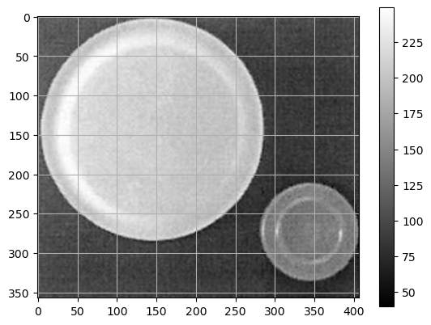

```python
plt.imshow(img, cmap='gray')
plt.colorbar()
plt.show()
```

1. Calculate the histogram and visualize it using matplotlib and pyplot.

```
usage: matplotlib.pyplot.hist(
         x, bins=None, range=None, density=False, weights=None,
         cumulative=False, bottom=None, histtype='bar', align='mid',
         orientation='vertical', rwidth=None, log=False, color=None,
         label=None, stacked=False, *, data=None, **kwargs
      )
```

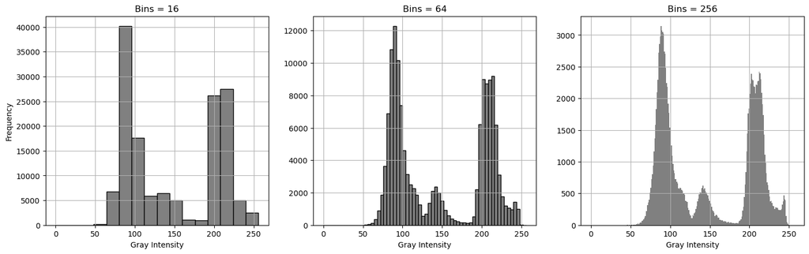

```python
# Visualize the histogram with matplotlib
# - Try at least 2 more different values for 'bins' (for example, 16, 64, 256)
# - Comment on how the appearance of the histogram changes when varying 'bins.

# Flatten the image to 1D (x) because hist expects a one-dimensional array
pixels = img.reshape(-1)

plt.figure(figsize=(18, 5))

# Case 1: bins = 16
plt.subplot(1, 3, 1)
plt.hist(x=pixels, bins=16, range=[0, 256], color='gray', edgecolor='black')
plt.title("Bins = 16")
plt.xlabel("Gray Intensity"); plt.ylabel("Frequency")

# Case 2: bins = 64
plt.subplot(1, 3, 2)
plt.hist(x=pixels, bins=64, range=[0, 256], color='gray', edgecolor='black')
plt.title("Bins = 64")
plt.xlabel("Gray Intensity")

# Case 3: bins = 256 (Maximum detail for 8 bits)
plt.subplot(1, 3, 3)
plt.hist(x=pixels, bins=256, range=[0, 256], color='gray')
plt.title("Bins = 256")
plt.xlabel("Gray Intensity")

plt.show()


#plot.hist(img.resahpe(-1), bins=256, range=[0,256])
#plt.show()
```

2. Do the same using the “seaborn” package.

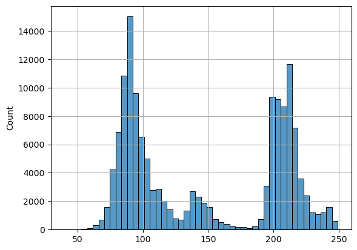

```python
sns.histplot(img.reshape(-1))
plt.show()
```

3. Compute a smoothed version of the histogram using KDE from the

“seaborn” package.

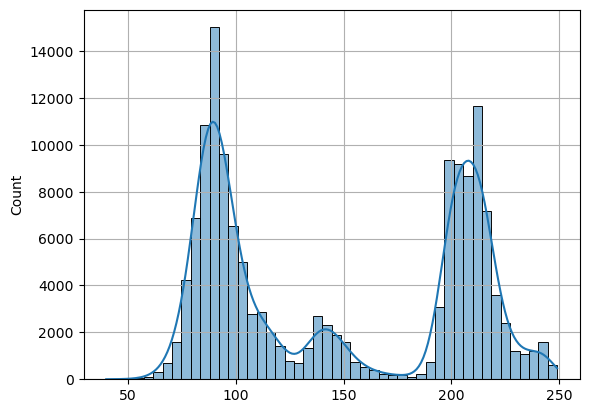

```python
sns.histplot(img.reshape(-1), kde=True)
plt.show()
```

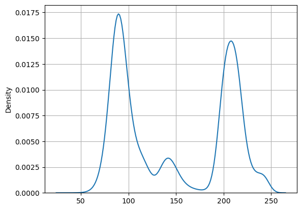

```python
sns.kdeplot(img.reshape(-1))       # only kde
plt.show()
```

**Exercise 2 (0.05 pts):** Apply multilevel thresholding to 'plates.png'.

1. What is the optimal number of levels?

The optimal number is 3 levels (or classes).

Class 1 (Background): The darkest part of the image.

2. How does the histogram change?

The original histogram is a "continuous" curve with peaks and valleys. The histogram of the segmented image becomes discrete: it will only have bars (non-zero frequency) at the 3 values you have chosen ($V_1, V_2, V_3$). The rest of the histogram will be empty.

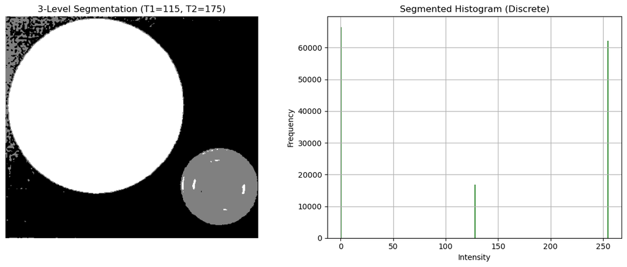

```python
# Choose your thresholds and class values based on the histogram.
# Replace with your own values.

# Example for 3 levels (you may change the number of levels):
# Class 1: img < T1        -> V1
# Class 2: T1 <= img < T2  -> V2
# Class 3: img >= T2       -> V3

# T: Threshold
# V: Value

thresholded_img = img.copy()

# Define Thresholds (T) based on histogram valleys (theory)
T1 = 115  # Separates background from shadow
T2 = 175  # Separates shadow from plate

# Define Values (V) for each class (0=Black, 128=Gray, 255=White)
V1 = 0
V2 = 128
V3 = 255

# Apply multilevel thresholding
# Class 1: Background
thresholded_img[img < T1] = V1

# Class 2: Shadows/Edges (Between T1 and T2)
thresholded_img[(img >= T1) & (img < T2)] = V2

# Class 3: Plates (Greater than T2)
thresholded_img[img >= T2] = V3

# -------------------------------------------------------------------------
# Visualization
# -------------------------------------------------------------------------
plt.figure(figsize=(12, 5))

# 1. Segmented Image
plt.subplot(1, 2, 1)
plt.imshow(thresholded_img, cmap='gray')
plt.title(f'3-Level Segmentation (T1={T1}, T2={T2})')
plt.axis('off')

# 2. Resulting Histogram
plt.subplot(1, 2, 2)
# We use bins=256 to clearly see that there are only 3 bars
sns.histplot(thresholded_img.reshape(-1), bins=256, color='green')
plt.title('Segmented Histogram (Discrete)')
plt.xlabel('Intensity')
plt.ylabel('Frequency')

plt.tight_layout()
plt.show()
```

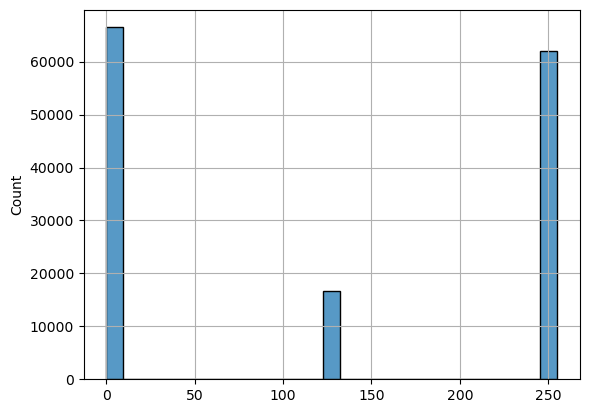

```python
sns.histplot(thresholded_img.reshape(-1))
plt.show()
```

**Exercise 3 (0.05 pts):** Read and visualize the image 'avocado.png', and:

1. Check the bimodal distribution of the pixels.
2. What intensity threshold would you use to segment the avocado? 130
3. Segment the image using the Otsu method. What is the estimated optimal threshold? 153.0

**Key Concepts**

***Otsu Method***: The Otsu method is used to perform automatic image thresholding in order to separate an image into foreground and background. It works by choosing the threshold that minimizes the intra-class variance (or maximizes the inter-class variance) of the pixel intensities, meaning, it finds the value that best separates the two classes.

```
Min pixel value = 4
Max pixel value = 255
```

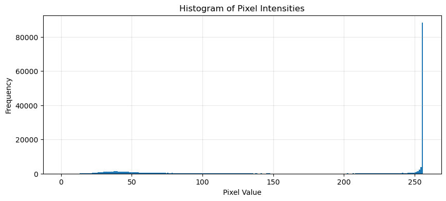

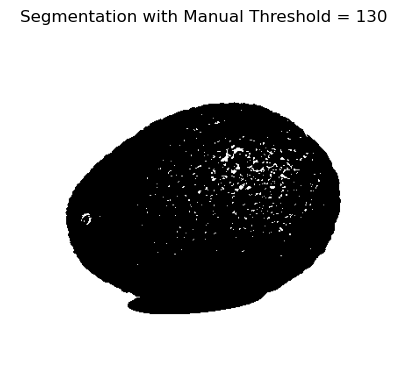

```python
# Load and visualize 'avocado.png' in grayscale and inspect its histogram.
# Inspect the minimum and maximum pixel values
#    Ex.: np.min(img) and np.max(img)
# Plot the histogram of pixel intensities
# Given the histogram, decide where you would place a manual threshold to separate the avocado from the background


# Load the image in grayscale
img = cv2.imread('./images/avocado.png', cv2.IMREAD_GRAYSCALE)

if img is not None:
    # Inspect the minimum and maximum pixel values
    print('Min pixel value =', np.min(img))
    print('Max pixel value =', np.max(img))

    # Plot the histogram of pixel intensities to decide the threshold
    plt.figure(figsize=(10, 4))
    plt.hist(img.ravel(), 256, [0, 256])
    plt.title('Histogram of Pixel Intensities')
    plt.xlabel('Pixel Value')
    plt.ylabel('Frequency')
    plt.grid(True, alpha=0.3)
    plt.show()

    # --- MANUAL THRESHOLD CALCULATION ---
    manual_threshold = 130

    # Apply the manual threshold to segment the image
    # Pixels > manual_threshold will be set to 255 (white), others to 0 (black)
    _, segmented_img_manual = cv2.threshold(img, manual_threshold, 255, cv2.THRESH_BINARY)

    # Visualize the result
    plt.figure(figsize=(5, 5))
    plt.imshow(segmented_img_manual, cmap='gray')
    plt.title(f'Segmentation with Manual Threshold = {manual_threshold}')
    plt.axis('off')
    plt.show()

else:
    print("Error: Image 'avocado.png' not found. Check the path.")
```

Otsu's thresholding

```
Estimated optimal threshold = 153.0
```

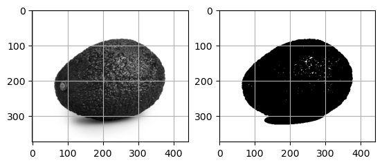

```python
threshold, thresholded_img = cv2.threshold(img, 0, 255, cv2.THRESH_OTSU)
print('Estimated optimal threshold =', threshold)
fig, ax = plt.subplots(1,2)
ax[0].imshow(img, cmap='gray')
ax[1].imshow(thresholded_img, cmap='gray')
plt.show()
```

**Exercise 4 (0.05):** Read and visualize the image 'CT.png', and:

1. Inspect the intensity distribution of the pixels.
2. What intensity threshold would you use to segment the lungs? 60.0
3. Try to segment the lungs using the Otsu method. What is the estimated optimal threshold? 51.0

```
Min pixel value = 0
Max pixel value = 198
```

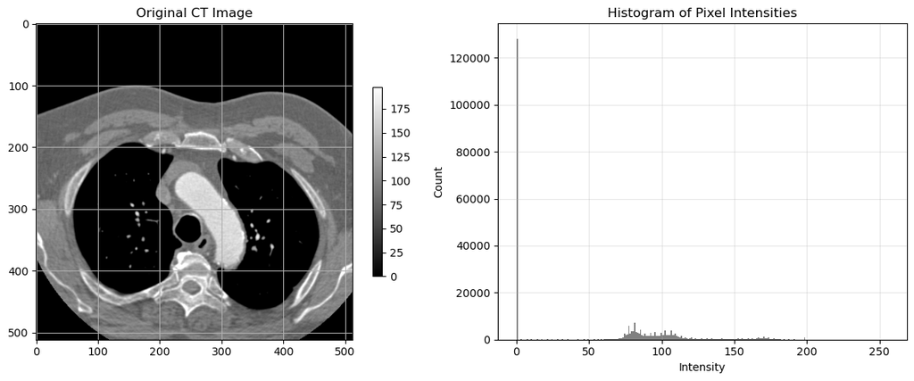

```
Manual Threshold selected: 60
```

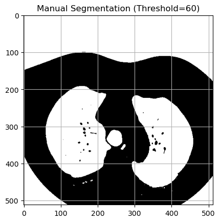

```python
# Inspect the intensity distriibution of 'CT.png'
# Propose a manual threshold for segmenting the lungs based on the histogram
# Apply it and visualize the result

# 1. Load the image
img_path = './images/CT.png'
img = cv2.imread(img_path, cv2.IMREAD_GRAYSCALE)

if img is None:
  sys.exit('Input image not found, check the path')

# 2. Inspect intensity distribution (Histogram)
print('Min pixel value =', np.min(img))
print('Max pixel value =', np.max(img))

plt.figure(figsize=(12, 5))

# Plot Image
plt.subplot(1, 2, 1)
plt.imshow(img, cmap='gray')
plt.title('Original CT Image')
plt.colorbar(shrink=0.6)

# Plot Histogram
plt.subplot(1, 2, 2)
plt.hist(img.ravel(), bins=256, range=[0, 256], color='gray')
plt.title('Histogram of Pixel Intensities')
plt.xlabel('Intensity')
plt.ylabel('Count')
plt.grid(True, alpha=0.3)

plt.tight_layout()
plt.show()

# ---------------------------------------------------------------------
# 3. Manual Segmentation
# ---------------------------------------------------------------------
# We want to segment the lungs (dark pixels).
# Based on the histogram, we choose a threshold in the valley between
# the dark peak (air) and the gray peak (tissue).
manual_thr = 60

print(f"Manual Threshold selected: {manual_thr}")

# We use THRESH_BINARY_INV because we want the DARK pixels (lungs) to be white (255)
# Logic: If pixel < manual_thr -> 255 (Foreground/Lungs), Else -> 0 (Background)
_, manual_seg = cv2.threshold(img, manual_thr, 255, cv2.THRESH_BINARY_INV)

# Visualize the result
plt.figure()
plt.imshow(manual_seg, cmap='gray')
plt.title(f'Manual Segmentation (Threshold={manual_thr})')
plt.show()
```

Otsu's thresholding

```
Estimated optimal threshold (Otsu) = 51.0
```

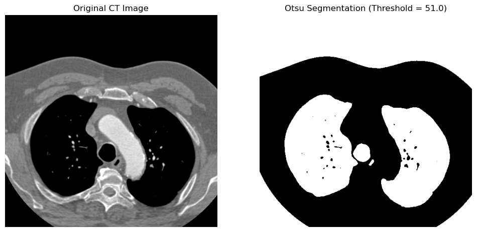

```python
# Apply Otsu's method as in exercise 4 to compare both segmentations.

# We use THRESH_BINARY_INV + THRESH_OTSU because the lungs are dark (air)
# and we want them to be the foreground (white) in the mask.
otsu_threshold, otsu_seg = cv2.threshold(img, 0, 255, cv2.THRESH_BINARY_INV + cv2.THRESH_OTSU)

print(f'Estimated optimal threshold (Otsu) = {otsu_threshold}')

# Visualize the comparison
fig, ax = plt.subplots(1, 2, figsize=(12, 6))

# Original Image
ax[0].imshow(img, cmap='gray')
ax[0].set_title('Original CT Image')
ax[0].axis('off')

# Otsu Segmentation
ax[1].imshow(otsu_seg, cmap='gray')
ax[1].set_title(f'Otsu Segmentation (Threshold = {otsu_threshold})')
ax[1].axis('off')

plt.show()
```

**Exercise 5 (0.10 pts):** Using the auxiliary functions provided next:

1. Apply the Gaussian Mixture Model (GMM) method (e.g. the implementation in scikit-learn) to 'CT.png' to segment **other parts** of the image. First exclude the background and the lungs and try different number of Gaussians.
2. Would it be possible to additionally segment the bones (whitest parts)?

In a CT scan, bones are the densest and brightest structures (highest pixel values, located on the far right of the histogram). By fitting a GMM with enough components (e.g., $k=3$ or $k=4$), the algorithm will assign one of the Gaussians specifically to these high values (the Gaussian with the highest mean $\mu$). To segment the bones, we would simply select the pixels that have the highest probability of belonging to that specific Gaussian.

**Key Concepts**

***Gaussian Mixture Model (GMM)***: A Gaussian Mixture Model is a probabilistic model that assumes all data points are generated from a mixture of a finite number of Gaussian distributions with certain parameters.

Some helper functions we use later.

```python
def fit_GMM(img, nb_gaussians, plot_stds=False):
  """ Fit GMM given the desired number of Gaussians. """

  gmm = mixture.GaussianMixture(n_components=nb_gaussians, max_iter=1000, covariance_type='full', random_state=1).fit(img.reshape(-1, 1))
  ordered_mu, ordered_std, ordered_pi, order = find_GMM_statistics(gmm)
  gaussian_colors = ['b','g','r','c','m','y']    # max 6 gaussians, add more if necessary
  print('Means = ', ordered_mu)
  print('Stds = ', ordered_std)
  print('Pis = ', ordered_pi)
  for i in range(nb_gaussians):
    plot_gaussian_and_stds(np.array([np.min(img), np.max(img)]), ordered_mu[i], ordered_std[i], ordered_pi[i], gaussian_colors[i], plot_stds, alpha=0.8)

  return gmm, ordered_mu, ordered_std, ordered_pi, order

def find_GMM_statistics(gmm):
  """ Determine which one is the first (lower mean),
      the second, the third, etc.  Gaussian to consistently color
      them in the plots,
      visualize the masks, etc. """

  all_means = np.array(gmm.means_[:, 0]).flatten()
  all_covariances = gmm.covariances_.flatten()

  order = np.argsort(all_means)  # this is also the label of clusters, return also 'order', useful to modify the cluster's label if necessary
  ordered_mu = all_means[order]
  ordered_std = np.sqrt(all_covariances[order])
  ordered_pi = gmm.weights_[order]

  return ordered_mu, ordered_std, ordered_pi, order

def plot_gaussian_and_stds(gaussians_range, mu, std, pi, color, plot_stds=False, alpha=1):
  """ Plot the Gaussian given by mu, std and pi.
      If plot_stds, additionally plot vertical lines corresponding to
      +-1SD, +-2SD, +-3SD """

  xmin, xmax = gaussians_range
  x = np.linspace(xmin, xmax, 1000)
  p = norm.pdf(x, mu, std) * pi
  if plot_stds:
      # plt.axvline(mu + std, 0, 1, label='pyplot vertical line', c=color)
    plt.axvline(mu + std, 0, 1, c=color, ls='--', alpha=0.75)
    plt.axvline(mu - std, 0, 1, c=color, ls='--', alpha=0.75)

    plt.axvline(mu + 2 * std, 0, 1, c=color, ls='-.', alpha=0.5)
    plt.axvline(mu - 2 * std, 0, 1, c=color, ls='-.', alpha=0.5)

    plt.axvline(mu + 3 * std, 0, 1, c=color, ls=':', alpha=0.25)
    plt.axvline(mu - 3 * std, 0, 1, c=color, ls=':', alpha=0.25)

    plt.plot(x, p, color, linewidth=2, alpha=alpha,
      label="Mean = {:.2f}; STD = {:.2f}; Weight = {:.2f}".format(mu, std, pi))
```

```
Means =  [ 0.         98.01459654]
Stds =  [1.00000000e-03 3.22300677e+01]
Pis =  [0.66329405 0.33670595]
```

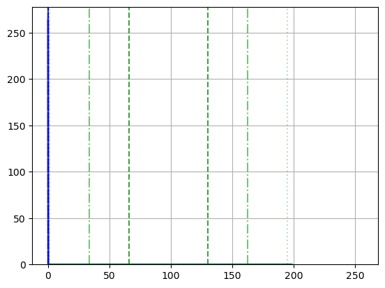

```
Means =  [  0.          88.06644761 166.57663669]
Stds =  [1.00000000e-03 1.97418048e+01 1.13603936e+01]
Pis =  [0.66329416 0.29404119 0.04266465]
```

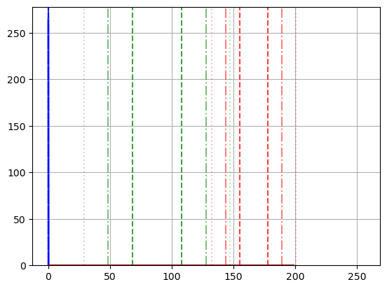

```
Means =  [  0.          85.83298041 106.65996245 166.15825235]
Stds =  [1.00000000e-03 1.95005277e+01 4.68804537e+00 1.17476598e+01]
Pis =  [0.66329416 0.2637267  0.02958804 0.0433911 ]
```

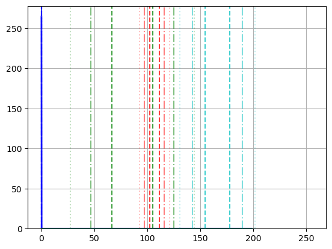

```python
other_colors = img[np.where(thresholded_img==255)]      # exclude background and lungs
plt.hist(other_colors.reshape(-1), bins=256, range=[0, 256], density=True)    # density for probability density instead of total count

gmm, ordered_mu, ordered_std, ordered_pi, order=fit_GMM(other_colors, nb_gaussians=2, plot_stds=True)
plt.show()

plt.figure()
plt.hist(other_colors.reshape(-1), bins=256, range=[0, 256], density=True)
gmm, ordered_mu, ordered_std, ordered_pi, order=fit_GMM(other_colors, nb_gaussians=3, plot_stds=True)
plt.show()

plt.figure()
plt.hist(other_colors.reshape(-1), bins=256, range=[0, 256], density=True)
gmm, ordered_mu, ordered_std, ordered_pi, order=fit_GMM(other_colors, nb_gaussians=4, plot_stds=True)
plt.show()
```

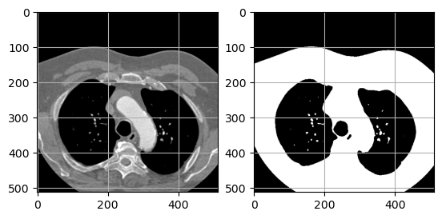

```python
threshold = 50

mask = np.zeros_like(img)
mask[np.where(img > threshold)] = 1

fig, ax = plt.subplots(1, 2)
ax[0].imshow(img, cmap='gray')
ax[1].imshow(mask, cmap='gray')
plt.show()
```

```
Means =  [ 92.00873646 157.66226977]
Stds =  [13.76947058 19.99808484]
Pis =  [0.83491128 0.16508872]
```

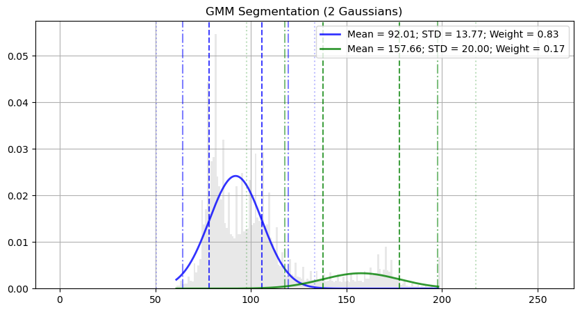

```
Means =  [ 80.85447484 103.26768448 157.10160637]
Stds =  [ 5.90147829  9.05724362 20.16061991]
Pis =  [0.42394259 0.40736036 0.16869706]
```

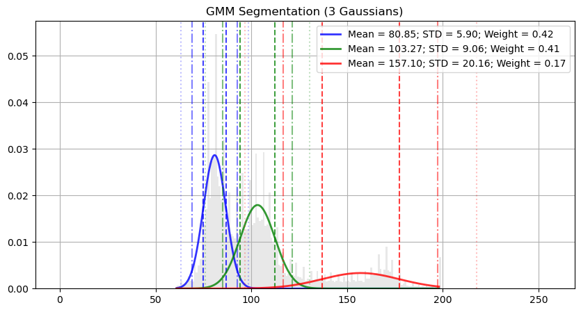

```
Means =  [ 81.17211553 102.96700712 129.27389615 167.83000099]
Stds =  [ 6.0462928   7.3217149  11.21054908 13.17649591]
Pis =  [0.44490598 0.36075886 0.07853736 0.11579779]
```

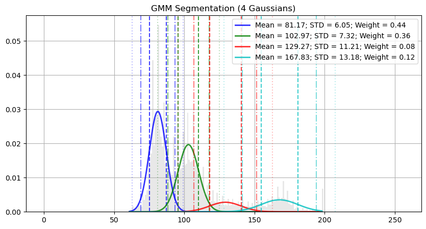

```python
# -------------------------------------------------------------------------
# EXERCISE 5: MAIN EXECUTION
# -------------------------------------------------------------------------

# Load image
img = cv2.imread('./images/CT.png', cv2.IMREAD_GRAYSCALE)

if img is not None:
    # Pre-processing: Exclude background and lungs
    # We established in Ex 4 that a threshold around 60 separates air/lungs from body.
    threshold = 60

    # We extract only the pixels belonging to the body (soft tissue + bone)
    # This removes the large peak at 0 (background/air) from the analysis
    other_colors = img[img > threshold]

    # GMM with different number of Gaussians (2, 3, 4)

    # --- Case k=2 ---
    plt.figure(figsize=(10, 5))
    # Plot normalized histogram of the body data (density=True)
    plt.hist(other_colors.reshape(-1), bins=256, range=[0, 256], density=True, color='lightgray', alpha=0.5)
    plt.title("GMM Segmentation (2 Gaussians)")
    # Fit GMM and plot
    gmm, ordered_mu, ordered_std, ordered_pi, order = fit_GMM(other_colors, nb_gaussians=2, plot_stds=True)
    plt.legend()
    plt.show()

    # --- Case k=3 ---
    plt.figure(figsize=(10, 5))
    plt.hist(other_colors.reshape(-1), bins=256, range=[0, 256], density=True, color='lightgray', alpha=0.5)
    plt.title("GMM Segmentation (3 Gaussians)")
    gmm, ordered_mu, ordered_std, ordered_pi, order = fit_GMM(other_colors, nb_gaussians=3, plot_stds=True)
    plt.legend()
    plt.show()

    # --- Case k=4 ---
    # With 4 Gaussians, one of them usually isolates the bones (highest mean) very well
    plt.figure(figsize=(10, 5))
    plt.hist(other_colors.reshape(-1), bins=256, range=[0, 256], density=True, color='lightgray', alpha=0.5)
    plt.title("GMM Segmentation (4 Gaussians)")
    gmm, ordered_mu, ordered_std, ordered_pi, order = fit_GMM(other_colors, nb_gaussians=4, plot_stds=True)
    plt.legend()
    plt.show()

else:
    print("Error: Image 'CT.png' not found.")
```

#### Clustering

**Exercise 6 (0.05 pts):** Using 'CT.png':

1. Try **several times** k-means specifying a different number of clusters.
2. What differences, if any, do you observe between each run?

As the number of clusters ($k$) increases, the algorithm segments the image into more granular levels of detail. A lower $k$ only separates the regions with high contrast (e.g., background vs. foreground), while a higher $k$ allows the model to differentiate between tissues or materials with more similar intensity values.

**Key Concepts**

***K-means***: K-means is an iterative clustering algorithm that groups similar data points together based on their distance to a central point, called the centroid. The centroids represents the centers of the clusters and are calculated as the means (or medians) of the points in the cluster.

We use the functions as imported from the scikit-learn library.

Define a convenience function to compute and show the k-means results.

```python
def RunKMeans(img,k):
  kmeans = KMeans(n_clusters=k, n_init="auto").fit(img.reshape(-1, 1))
  fig, ax = plt.subplots(1, 2)
  ax[0].imshow(img, cmap='gray')
  ax[1].imshow(kmeans.labels_.reshape(img.shape))
  # plot image + labels overlayed
  plt.figure()
  plt.imshow(img, cmap='gray')
  plt.imshow(kmeans.labels_.reshape(img.shape), alpha=0.2)
  plt.colorbar()
  plt.show()
```

Run k-means three times with different values of k (for example k=2, 3, 4) For each k, visualize the label mage and the overlay

Example: RunKMeans(img, 2)

Run 1

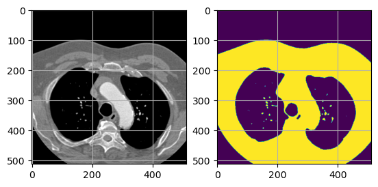

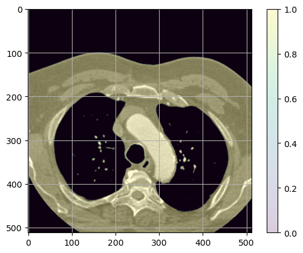

```python
# Run K-means with k=2
RunKMeans(img, 2)
```

Run 2

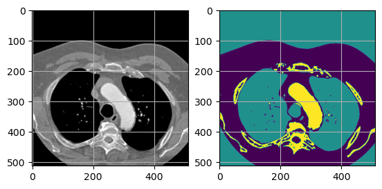

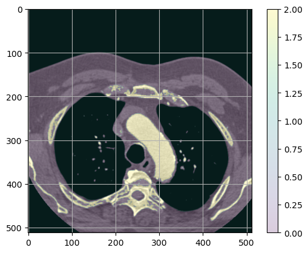

```python
# Run K-means with k=3
RunKMeans(img, 3)
```

Run 3

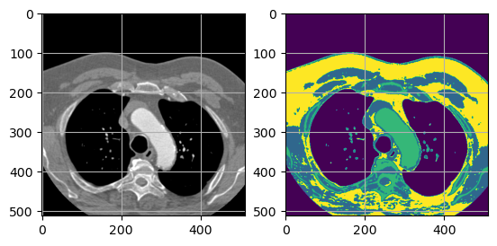

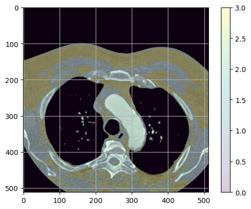

```python
# Run K-means with k=4
RunKMeans(img, 4)
```

**Exercise 7 (0.05 pts):** Read and visualize 'puncher.png' and its corresponding histogram. Then:

1. Apply k-means to segment the object.
2. Apply Meanshift to segment the object. Try different 'bandwidth' values.

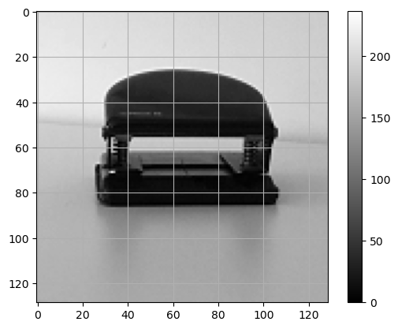

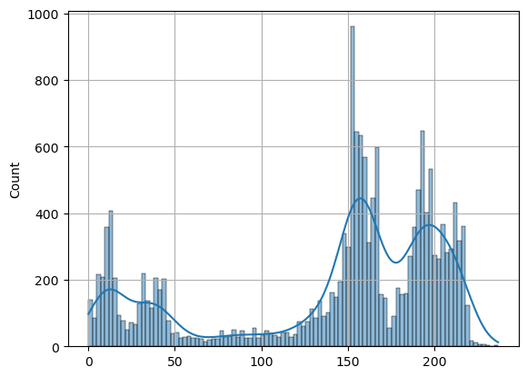

```python
img = cv2.imread(images_path + 'puncher.png', cv2.IMREAD_GRAYSCALE)
if img is None:
  sys.exit('Input image not found, check the path')

plt.imshow(img, cmap='gray')
plt.colorbar()
plt.figure()
sns.histplot(img.reshape(-1), bins=100, kde=True)
plt.show()
```